# Exam Preparation

## Task 5: Distribution of random numbers

1. Create a numeric vector `runif(n = 1000, min = 1, max = 100) |> hist()` and run the code. What does the code do? Remove `|> hist()` and run the code again. What does the code do?
2. Create a numeric vector `rnorm(n = 1000, mean = 500, sd = 150) |> hist()` and run the code. What does the code do? Remove `|> hist()` and run the code again. What does the code do?

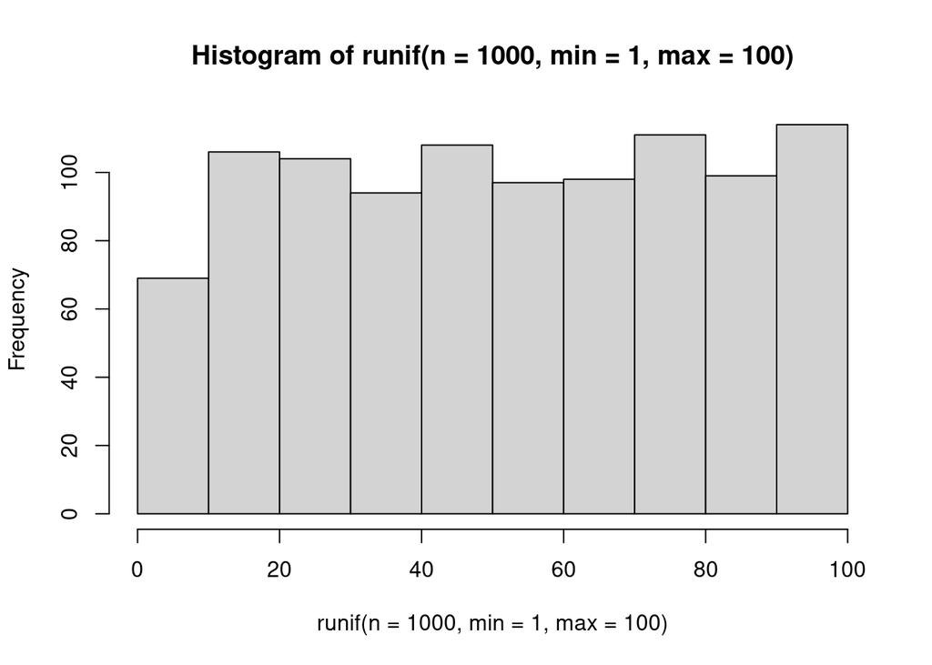

```r
runif(n = 1000, min = 1, max = 100) |> hist()
```

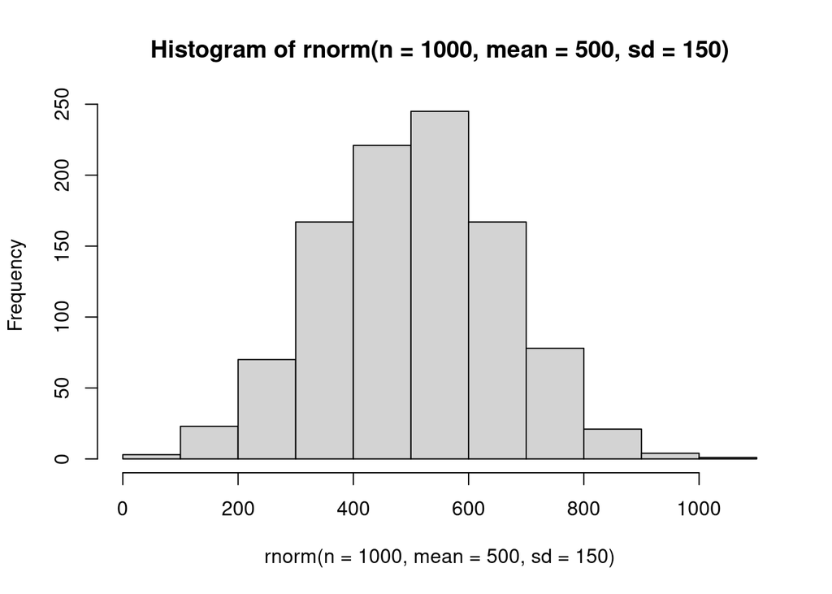

```r
rnorm(n = 1000, mean = 500, sd = 150) |> hist()
```

## Task 6: Logical vectors

1. Create a numeric vector using `rnorm(n = 1000, mean = 50, sd = 5)` and use the assignment operator to store it in an object called `norm100`. Run the code.
2. Write:
- `mean(norm100)` and run the code. What does the code do?
- `norm100 >= 50` and run the code. What does the code do?
- `sum(norm100 >= 50)` and run the code. What does the code do?
- `mean(norm100 >= 50)` and run the code. What does the code do?

```r
norm_dist <- rnorm(n = 1000, mean = 50, sd = 5)

mean(norm_dist)
```

```
[1] 49.93697
```

```r
norm_dist >= 50
```

```
   [1]  TRUE FALSE FALSE FALSE FALSE FALSE  TRUE  TRUE  TRUE FALSE FALSE FALSE
  [13]  TRUE FALSE FALSE  TRUE FALSE  TRUE FALSE FALSE FALSE FALSE  TRUE  TRUE
  [25]  TRUE  TRUE FALSE  TRUE  TRUE  TRUE  TRUE  TRUE FALSE FALSE  TRUE  TRUE
  [37] FALSE FALSE FALSE FALSE FALSE  TRUE FALSE FALSE FALSE  TRUE  TRUE  TRUE
  [49] FALSE  TRUE  TRUE FALSE FALSE FALSE  TRUE FALSE  TRUE  TRUE FALSE  TRUE
  [61] FALSE  TRUE FALSE FALSE FALSE  TRUE FALSE  TRUE  TRUE FALSE  TRUE FALSE
  [73] FALSE  TRUE  TRUE  TRUE  TRUE  TRUE FALSE  TRUE  TRUE FALSE  TRUE  TRUE
  [85] FALSE  TRUE  TRUE  TRUE FALSE FALSE FALSE  TRUE FALSE FALSE  TRUE  TRUE
  [97]  TRUE  TRUE FALSE  TRUE FALSE FALSE FALSE  TRUE  TRUE  TRUE  TRUE  TRUE
 [109]  TRUE FALSE FALSE FALSE FALSE  TRUE  TRUE FALSE FALSE  TRUE FALSE FALSE
 [121] FALSE  TRUE FALSE FALSE FALSE FALSE FALSE FALSE  TRUE  TRUE FALSE  TRUE
 [133] FALSE FALSE FALSE  TRUE FALSE FALSE  TRUE FALSE  TRUE FALSE  TRUE  TRUE
 [145] FALSE  TRUE  TRUE FALSE  TRUE  TRUE  TRUE FALSE FALSE  TRUE FALSE FALSE
 [157]  TRUE  TRUE FALSE  TRUE FALSE  TRUE FALSE  TRUE  TRUE  TRUE FALSE  TRUE
 [169] FALSE FALSE FALSE  TRUE  TRUE  TRUE FALSE FALSE  TRUE FALSE FALSE  TRUE
```

[output cut: 69 more lines]

```r
sum(norm_dist >= 50)
```

```
[1] 502
```

```r
mean(norm_dist >= 50)
```

```
[1] 0.502
```

## Task 7 (stretch goal)

In this task, we will use the `flights` data object of the `nycflights13` package. The `flights` data object contains information about all flights that departed from NYC (e.g., EWR, JFK and LGA) in 2013. The data object contains 336,776 rows and 19 columns.

1. Use the `flights` data object with `mutate()` to create `delayed`, a variable that displays whether a flight was delayed (`arr_delay > 0`).
2. Use relocate to move `delayed` to the front of the data frame. Run the code. What vector type is the `delayed` variable?
3. Then, remove all rows that contain an NA in `delayed`.
4. Finally, create a summary table with `summarise()` that shows
- How many flights were delayed
- What proportion of flights were delayed

```r
flights |>
  mutate(delayed = arr_delay > 0) |>
  relocate(delayed) |>
  filter(!is.na(delayed)) |>
  summarise(sum = sum(delayed),
            prop = mean(delayed))
```

```
# A tibble: 1 × 2
     sum  prop
   <int> <dbl>
1 133004 0.406
```

## Scholarly writing

Scholarly articles require much more detail in their front matter than simply a title and an author. Quarto provides a rich set of YAML metadata keys to describe these details. You can copy & paste from this example to your own report.

## Task 1: Front Matter

- Replace the values under author for name, orcid, email, and affiliation with your own
- Render the document to see the changes

## Task 2: Citations

1. Add the citation key for the paper “‘My flight arrives at 5 am, can you pick me up?’: The gatekeeping burden of the african academic” as an in-text reference to the sentence below

In @tilley2021my, the authors describe how visitors still expect a personal pick-up, despite the availability of taxi services.

2. Add the citation key for the paper “‘The rich will always be able to dispose of their waste’: a view from the frontlines of municipal failure in Makhanda, South Africa” as a citation at the end of the sentence below.

Inequality underpins waste management systems, structuring who can or cannot access services [@kalina2023rich].

## Bibliographies

Your folder already contains a `references.bib` file. One way of creating and adding to this file is by using the RStudio Visual Editor mode. Another way is by exporting a collection in Zotero reference management tool. Part of your homework will be to setup Zotero. For your literature research, you will then use Zotero and in your final report use an exported `.bib` file to cite references in your report. https://rbtl-fs24.github.io/website/project